# R Notebook

# First Session

**Understanding the data**

To design an effective visualization with a clear purpose, you must thoroughly understand your data. The following points will help you find the information you want to convey with your data:

- What kind of data is it? Nominal, ordinal, interval or ratio data?
- How do the different parts of the data relate to each other?
- Can you organize the data in a way that makes it easy for you to create your visualizations?
- What do you want to communicate with your data?

## The ggplot2 package

The grammar of graphics (ggplot)

To contruct a graph, we need

- data: a dataframe in tidyformat
- some mapping to include aesthetics elements
- a geometric representation of the aesthetics elements

The ggplot allows to manage those elements and adding to your graph as layers

First install pacman that will allow to install other packages

```r
# install.packages("pacman")
```

And now I will install the packages that we will use

```r
pacman::p_load(tidyverse, # several datascience packages
               palmerpenguins, # data
               gapminder, #data,
               gtsummary) # for tables)
```

We have everything ready

```r
head(penguins)
```

| species | island | bill_length_mm | bill_depth_mm | flipper_length_mm | body_mass_g | sex | year |
| --- | --- | --- | --- | --- | --- | --- | --- |
| Adelie | Torgersen | 39.1 | 18.7 | 181 | 3750 | male | 2007 |
| Adelie | Torgersen | 39.5 | 17.4 | 186 | 3800 | female | 2007 |
| Adelie | Torgersen | 40.3 | 18.0 | 195 | 3250 | female | 2007 |
| Adelie | Torgersen | NA | NA | NA | NA | NA | 2007 |
| Adelie | Torgersen | 36.7 | 19.3 | 193 | 3450 | female | 2007 |
| Adelie | Torgersen | 39.3 | 20.6 | 190 | 3650 | male | 2007 |

```r
View(penguins)
```

## My first graph

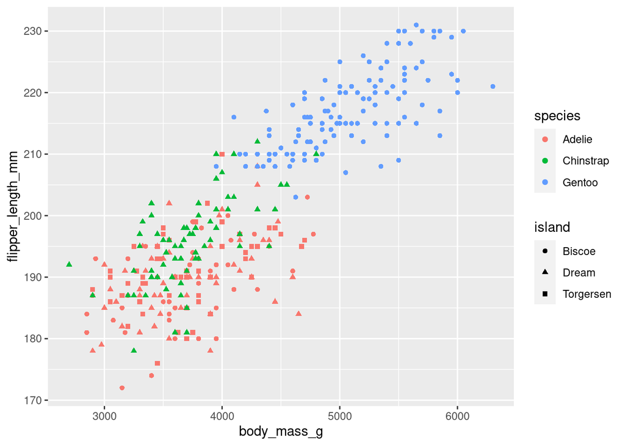

```r
penguins %>%
  ggplot(aes(x = body_mass_g,
             y = flipper_length_mm,
             color = species,
             shape = island)) +
  geom_point()
```

```r
covid_latvia <- read_csv("https://covid.ourworldindata.org/data/owid-covid-data.csv")
```

# Second session

## Packages

Run the first lines

## Explore the dataset

### Know your variables

- continuous: num or int
- categorical: fct or chr
- date/time

### summary

Summary of all the dataset

Summary of a specific variable (or vector in R vocabulary)

species

island

flipper_length

### dim

Give the **dim**ensions of the dataset in rows and columns

## Summary tables

#### With tables

By sex

By sex and species

by species and island

#### With gtsummary

all

by sex

by species

by island

only sex, species and body_mass_g (new: select)

## Visualize the dataset

### One variable

#### continuous: num or int

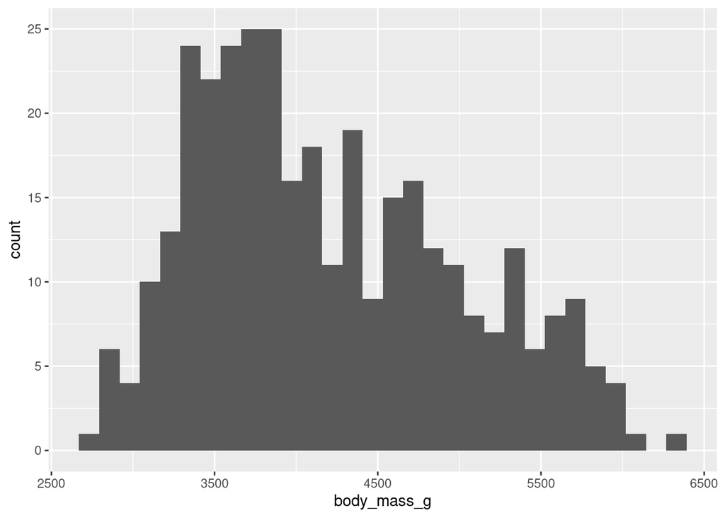

```r
penguins %>%
  ggplot(aes(x = body_mass_g)) +
  geom_histogram()
```

by flipper_length

only one specie (new: filter)

#### categorical: fct or chr

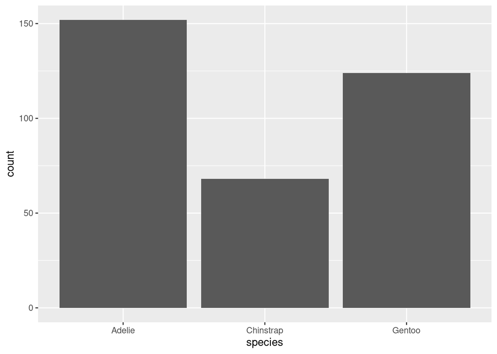

```r
penguins %>%
  ggplot(aes(x = species)) +
  geom_bar()
```

By island

### Two variables

#### number vs categorical

species vs body_mass_g

#### categorical vs categorical

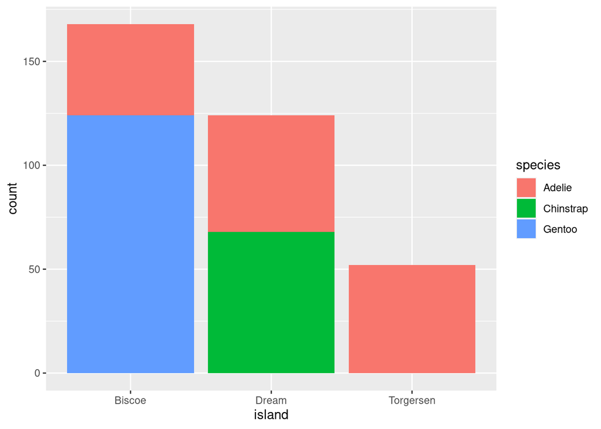

```r
penguins %>%
  ggplot(aes(x = island,
             fill = species)) +
  geom_bar()
```

### Time

See https://github.com/owid/covid-19-data/tree/master/public/data/vaccinations

## Second session last part, delete this header afterwards

### One variable

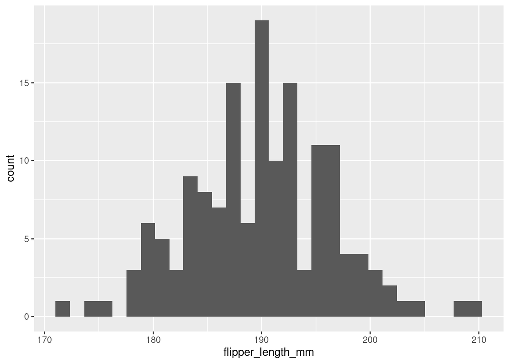

```r
penguins %>%
  filter(species == "Adelie") %>%
  ggplot(aes(x = flipper_length_mm)) +
  geom_histogram()
```

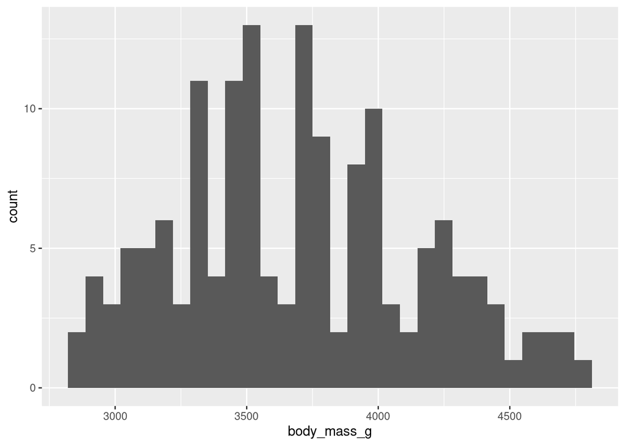

```r
penguins %>%
  filter(species == "Adelie") %>%
  ggplot(aes(x = body_mass_g)) +
  geom_histogram()
```

Try adjusting the bins

### Two variables: num vs num

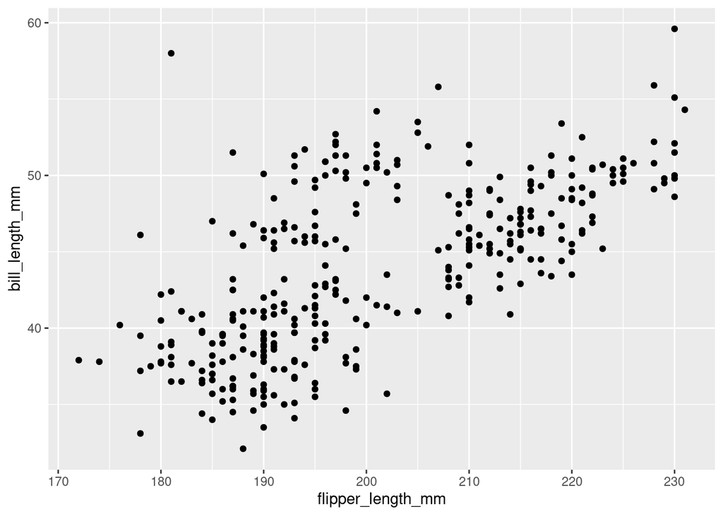

```r
penguins %>%
  ggplot(aes(x = flipper_length_mm,
             y = bill_length_mm)) +
  geom_point()
```

### Two variable num vs categorical

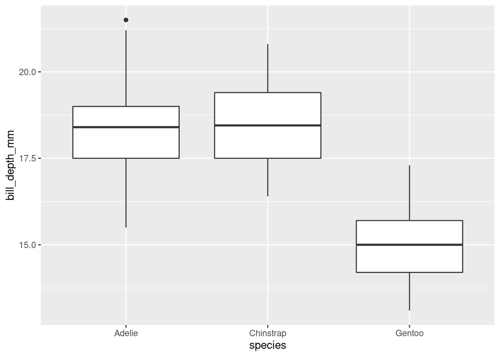

```r
penguins %>%
  ggplot(aes(x = species,
             y = bill_depth_mm)) +
  geom_boxplot()
```

Try with jitter

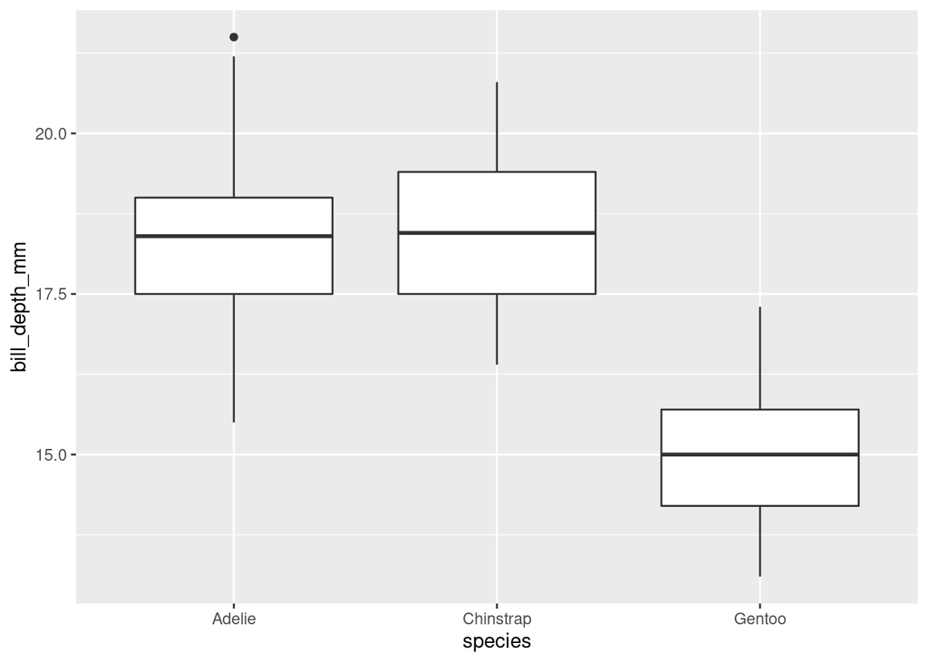

```r
penguins %>%
  ggplot(aes(x = species,
             y = bill_depth_mm)) +
  geom_boxplot()
```

add color, size, shape

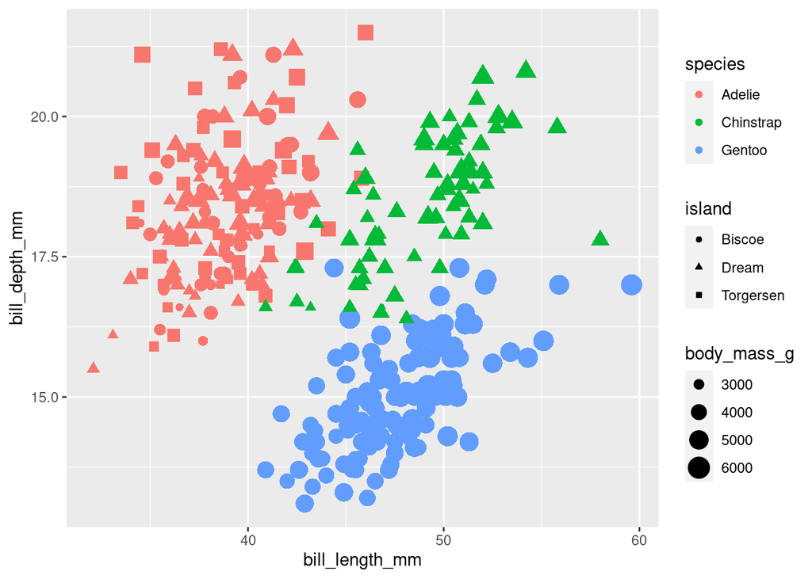

```r
penguins %>%
  ggplot(aes(x = bill_length_mm,
             y = bill_depth_mm,
             color = species,
             size = body_mass_g,
             shape = island)) +
  geom_point()
```

# Third session

```r
head(penguins)
```

| species | island | bill_length_mm | bill_depth_mm | flipper_length_mm | body_mass_g | sex | year |
| --- | --- | --- | --- | --- | --- | --- | --- |
| Adelie | Torgersen | 39.1 | 18.7 | 181 | 3750 | male | 2007 |
| Adelie | Torgersen | 39.5 | 17.4 | 186 | 3800 | female | 2007 |
| Adelie | Torgersen | 40.3 | 18.0 | 195 | 3250 | female | 2007 |
| Adelie | Torgersen | NA | NA | NA | NA | NA | 2007 |
| Adelie | Torgersen | 36.7 | 19.3 | 193 | 3450 | female | 2007 |
| Adelie | Torgersen | 39.3 | 20.6 | 190 | 3650 | male | 2007 |

```r
head(relig_income)
```

| religion | <$10k | $10-20k | $20-30k | $30-40k | $40-50k | $50-75k | $75-100k | $100-150k | >150k | Don't know/refused |
| --- | --- | --- | --- | --- | --- | --- | --- | --- | --- | --- |
| Agnostic | 27 | 34 | 60 | 81 | 76 | 137 | 122 | 109 | 84 | 96 |
| Atheist | 12 | 27 | 37 | 52 | 35 | 70 | 73 | 59 | 74 | 76 |
| Buddhist | 27 | 21 | 30 | 34 | 33 | 58 | 62 | 39 | 53 | 54 |
| Catholic | 418 | 617 | 732 | 670 | 638 | 1116 | 949 | 792 | 633 | 1489 |
| Don’t know/refused | 15 | 14 | 15 | 11 | 10 | 35 | 21 | 17 | 18 | 116 |
| Evangelical Prot | 575 | 869 | 1064 | 982 | 881 | 1486 | 949 | 723 | 414 | 1529 |

```r
gapminder_wide <- read_csv("https://bit.ly/gapminder-rsu")
head(gapminder_wide)
```

| continent | country | gdpPercap_1952 | gdpPercap_1957 | gdpPercap_1962 | gdpPercap_1967 | gdpPercap_1972 | gdpPercap_1977 | gdpPercap_1982 | gdpPercap_1987 | gdpPercap_1992 | gdpPercap_1997 | gdpPercap_2002 | gdpPercap_2007 | lifeExp_1952 | lifeExp_1957 | lifeExp_1962 | lifeExp_1967 | lifeExp_1972 | lifeExp_1977 | lifeExp_1982 | lifeExp_1987 | lifeExp_1992 | lifeExp_1997 | lifeExp_2002 | lifeExp_2007 | pop_1952 | pop_1957 | pop_1962 | pop_1967 | … |
| --- | --- | --- | --- | --- | --- | --- | --- | --- | --- | --- | --- | --- | --- | --- | --- | --- | --- | --- | --- | --- | --- | --- | --- | --- | --- | --- | --- | --- | --- | --- |
| Africa | Algeria | 2449.0082 | 3013.9760 | 2550.8169 | 3246.9918 | 4182.6638 | 4910.4168 | 5745.1602 | 5681.3585 | 5023.2166 | 4797.2951 | 5288.0404 | 6223.3675 | 43.077 | 45.685 | 48.303 | 51.407 | 54.518 | 58.014 | 61.368 | 65.799 | 67.744 | 69.152 | 70.994 | 72.301 | 9279525 | 10270856 | 11000948 | 12760499 | … |
| Africa | Angola | 3520.6103 | 3827.9405 | 4269.2767 | 5522.7764 | 5473.2880 | 3008.6474 | 2756.9537 | 2430.2083 | 2627.8457 | 2277.1409 | 2773.2873 | 4797.2313 | 30.015 | 31.999 | 34.000 | 35.985 | 37.928 | 39.483 | 39.942 | 39.906 | 40.647 | 40.963 | 41.003 | 42.731 | 4232095 | 4561361 | 4826015 | 5247469 | … |
| Africa | Benin | 1062.7522 | 959.6011 | 949.4991 | 1035.8314 | 1085.7969 | 1029.1613 | 1277.8976 | 1225.8560 | 1191.2077 | 1232.9753 | 1372.8779 | 1441.2849 | 38.223 | 40.358 | 42.618 | 44.885 | 47.014 | 49.190 | 50.904 | 52.337 | 53.919 | 54.777 | 54.406 | 56.728 | 1738315 | 1925173 | 2151895 | 2427334 | … |
| Africa | Botswana | 851.2411 | 918.2325 | 983.6540 | 1214.7093 | 2263.6111 | 3214.8578 | 4551.1421 | 6205.8839 | 7954.1116 | 8647.1423 | 11003.6051 | 12569.8518 | 47.622 | 49.618 | 51.520 | 53.298 | 56.024 | 59.319 | 61.484 | 63.622 | 62.745 | 52.556 | 46.634 | 50.728 | 442308 | 474639 | 512764 | 553541 | … |
| Africa | Burkina Faso | 543.2552 | 617.1835 | 722.5120 | 794.8266 | 854.7360 | 743.3870 | 807.1986 | 912.0631 | 931.7528 | 946.2950 | 1037.6452 | 1217.0330 | 31.975 | 34.906 | 37.814 | 40.697 | 43.591 | 46.137 | 48.122 | 49.557 | 50.260 | 50.324 | 50.650 | 52.295 | 4469979 | 4713416 | 4919632 | 5127935 | … |
| Africa | Burundi | 339.2965 | 379.5646 | 355.2032 | 412.9775 | 464.0995 | 556.1033 | 559.6032 | 621.8188 | 631.6999 | 463.1151 | 446.4035 | 430.0707 | 39.031 | 40.533 | 42.045 | 43.548 | 44.057 | 45.910 | 47.471 | 48.211 | 44.736 | 45.326 | 47.360 | 49.580 | 2445618 | 2667518 | 2961915 | 3330989 | … |

```r
glimpse(gapminder_wide)
```

```
## Rows: 142
## Columns: 38
## $ continent      <chr> "Africa", "Africa", "Africa", "Africa", "Africa", "Afri…
## $ country        <chr> "Algeria", "Angola", "Benin", "Botswana", "Burkina Faso…
## $ gdpPercap_1952 <dbl> 2449.0082, 3520.6103, 1062.7522, 851.2411, 543.2552, 33…
## $ gdpPercap_1957 <dbl> 3013.9760, 3827.9405, 959.6011, 918.2325, 617.1835, 379…
## $ gdpPercap_1962 <dbl> 2550.8169, 4269.2767, 949.4991, 983.6540, 722.5120, 355…
## $ gdpPercap_1967 <dbl> 3246.9918, 5522.7764, 1035.8314, 1214.7093, 794.8266, 4…
## $ gdpPercap_1972 <dbl> 4182.6638, 5473.2880, 1085.7969, 2263.6111, 854.7360, 4…
## $ gdpPercap_1977 <dbl> 4910.4168, 3008.6474, 1029.1613, 3214.8578, 743.3870, 5…
## $ gdpPercap_1982 <dbl> 5745.1602, 2756.9537, 1277.8976, 4551.1421, 807.1986, 5…
## $ gdpPercap_1987 <dbl> 5681.3585, 2430.2083, 1225.8560, 6205.8839, 912.0631, 6…
## $ gdpPercap_1992 <dbl> 5023.2166, 2627.8457, 1191.2077, 7954.1116, 931.7528, 6…
## $ gdpPercap_1997 <dbl> 4797.2951, 2277.1409, 1232.9753, 8647.1423, 946.2950, 4…
## $ gdpPercap_2002 <dbl> 5288.0404, 2773.2873, 1372.8779, 11003.6051, 1037.6452,…
```

[output cut: 25 more lines]

How many countries?

```r
gapminder_wide %>%
  count(country)
```

| country | n |
| --- | --- |
| Afghanistan | 1 |
| Albania | 1 |
| Algeria | 1 |
| Angola | 1 |
| Argentina | 1 |
| Australia | 1 |
| Austria | 1 |
| Bahrain | 1 |
| Bangladesh | 1 |
| Belgium | 1 |

[output cut: 132 more lines]

```r
n_distinct(gapminder_wide$country)
```

```
## [1] 142
```

Count continents

```r
gapminder_wide %>%
  count(continent)
```

| continent | n |
| --- | --- |
| Africa | 52 |
| Americas | 25 |
| Asia | 33 |
| Europe | 30 |
| Oceania | 2 |

```r
n_distinct(gapminder_wide$continent)
```

```
## [1] 5
```

## Wide vs long formats

### Let’s look at the columns: how many variables?

gdpPercap_1952:gdpPercap_2007

pop_1952:pop_2007

## Split-apply-combine

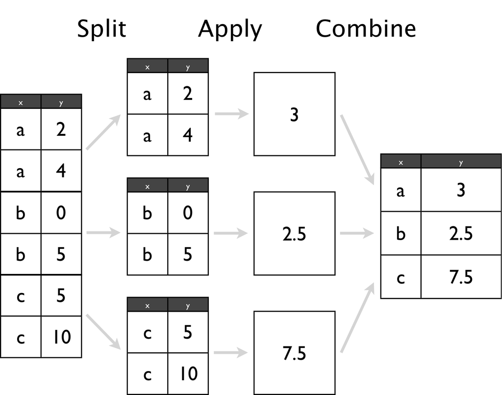

### Question: how has GDP per continent evolved per year?

```r
gapminder %>%
  # split
  group_by(continent, year) %>%
  # apply & combine
  summarise(mean = mean(gdpPercap))
```

| continent | year | mean |
| --- | --- | --- |
| Africa | 1952 | 1252.572 |
| Africa | 1957 | 1385.236 |
| Africa | 1962 | 1598.079 |
| Africa | 1967 | 2050.364 |
| Africa | 1972 | 2339.616 |
| Africa | 1977 | 2585.939 |
| Africa | 1982 | 2481.593 |
| Africa | 1987 | 2282.669 |
| Africa | 1992 | 2281.810 |
| Africa | 1997 | 2378.760 |

[output cut: 50 more lines]

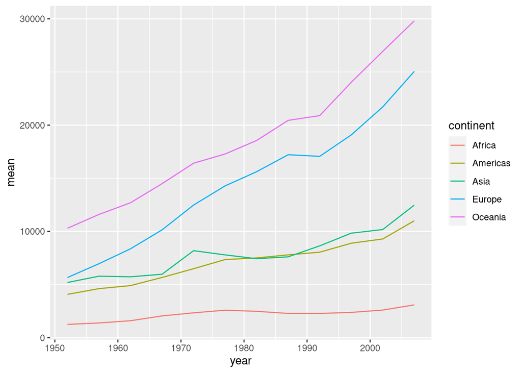

```r
gapminder %>%
  # split
  group_by(continent, year) %>%
  # apply & combine
  summarise(mean = mean(gdpPercap)) %>%
  ggplot(aes(x = year,
             y = mean,
             color = continent)) +
  geom_line()
```

### Question: how has POPULATION per continent evolved per year?

Select only the Baltic countries and explore their changes in gdp and population

Homework: See [<https://github.com/owid/covid-19-data/tree/master/public/data/vaccinations>](https://github.com/owid/covid-19-data/tree/master/public/data/vaccinations)

# Fourth session

compare gapminder wide vs long

Load the packages

```r
pacman::p_load(tidyverse, # several datascience packages
               palmerpenguins, # data
               gapminder, #data,
               gtsummary) # for tables)
```

## Data basics

#### Filtering

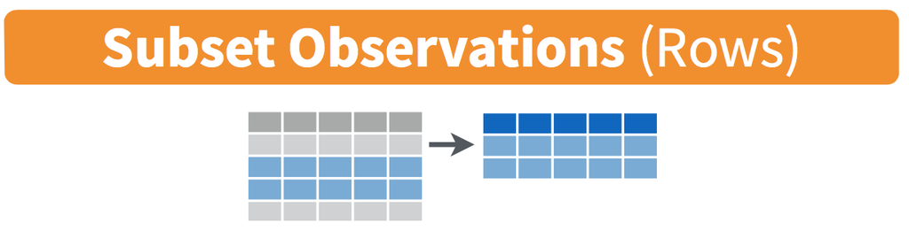

```r
penguins %>%
  filter(species == "Adelie")
```

| species | island | bill_length_mm | bill_depth_mm | flipper_length_mm | body_mass_g | sex | year |
| --- | --- | --- | --- | --- | --- | --- | --- |
| Adelie | Torgersen | 39.1 | 18.7 | 181 | 3750 | male | 2007 |
| Adelie | Torgersen | 39.5 | 17.4 | 186 | 3800 | female | 2007 |
| Adelie | Torgersen | 40.3 | 18.0 | 195 | 3250 | female | 2007 |
| Adelie | Torgersen | NA | NA | NA | NA | NA | 2007 |
| Adelie | Torgersen | 36.7 | 19.3 | 193 | 3450 | female | 2007 |
| Adelie | Torgersen | 39.3 | 20.6 | 190 | 3650 | male | 2007 |
| Adelie | Torgersen | 38.9 | 17.8 | 181 | 3625 | female | 2007 |
| Adelie | Torgersen | 39.2 | 19.6 | 195 | 4675 | male | 2007 |
| Adelie | Torgersen | 34.1 | 18.1 | 193 | 3475 | NA | 2007 |
| Adelie | Torgersen | 42.0 | 20.2 | 190 | 4250 | NA | 2007 |

[output cut: 142 more lines]

```r
penguins %>%
  filter(species == "Adelie" & island == "Dream")
```

| species | island | bill_length_mm | bill_depth_mm | flipper_length_mm | body_mass_g | sex | year |
| --- | --- | --- | --- | --- | --- | --- | --- |
| Adelie | Dream | 39.5 | 16.7 | 178 | 3250 | female | 2007 |
| Adelie | Dream | 37.2 | 18.1 | 178 | 3900 | male | 2007 |
| Adelie | Dream | 39.5 | 17.8 | 188 | 3300 | female | 2007 |
| Adelie | Dream | 40.9 | 18.9 | 184 | 3900 | male | 2007 |
| Adelie | Dream | 36.4 | 17.0 | 195 | 3325 | female | 2007 |
| Adelie | Dream | 39.2 | 21.1 | 196 | 4150 | male | 2007 |
| Adelie | Dream | 38.8 | 20.0 | 190 | 3950 | male | 2007 |
| Adelie | Dream | 42.2 | 18.5 | 180 | 3550 | female | 2007 |
| Adelie | Dream | 37.6 | 19.3 | 181 | 3300 | female | 2007 |
| Adelie | Dream | 39.8 | 19.1 | 184 | 4650 | male | 2007 |

[output cut: 46 more lines]

```r
penguins %>%
  filter(body_mass_g < 3000)
```

| species | island | bill_length_mm | bill_depth_mm | flipper_length_mm | body_mass_g | sex | year |
| --- | --- | --- | --- | --- | --- | --- | --- |
| Adelie | Dream | 37.5 | 18.9 | 179 | 2975 | NA | 2007 |
| Adelie | Biscoe | 34.5 | 18.1 | 187 | 2900 | female | 2008 |
| Adelie | Biscoe | 36.5 | 16.6 | 181 | 2850 | female | 2008 |
| Adelie | Biscoe | 36.4 | 17.1 | 184 | 2850 | female | 2008 |
| Adelie | Dream | 33.1 | 16.1 | 178 | 2900 | female | 2008 |
| Adelie | Biscoe | 37.9 | 18.6 | 193 | 2925 | female | 2009 |
| Adelie | Torgersen | 38.6 | 17.0 | 188 | 2900 | female | 2009 |
| Chinstrap | Dream | 43.2 | 16.6 | 187 | 2900 | female | 2007 |
| Chinstrap | Dream | 46.9 | 16.6 | 192 | 2700 | female | 2008 |

You can use other operators beyond just the `==` operator that tests for equality:

- `>` corresponds to “greater than”
- `<` corresponds to “less than”
- `>=` corresponds to “greater than or equal to”
- `<=` corresponds to “less than or equal to”
- `!=` corresponds to “not equal to.” The `!` is used in many programming languages to indicate “not.”

[`&`](https://rdrr.io/r/base/Logic.html) is “and”, [`|`](https://rdrr.io/r/base/Logic.html) is “or”, and [`!`](https://rdrr.io/r/base/Logic.html) is “not”.

```r
penguins %>%
  filter(species == "Adelie" &  island != "Torgersen")
```

| species | island | bill_length_mm | bill_depth_mm | flipper_length_mm | body_mass_g | sex | year |
| --- | --- | --- | --- | --- | --- | --- | --- |
| Adelie | Biscoe | 37.8 | 18.3 | 174 | 3400 | female | 2007 |
| Adelie | Biscoe | 37.7 | 18.7 | 180 | 3600 | male | 2007 |
| Adelie | Biscoe | 35.9 | 19.2 | 189 | 3800 | female | 2007 |
| Adelie | Biscoe | 38.2 | 18.1 | 185 | 3950 | male | 2007 |
| Adelie | Biscoe | 38.8 | 17.2 | 180 | 3800 | male | 2007 |
| Adelie | Biscoe | 35.3 | 18.9 | 187 | 3800 | female | 2007 |
| Adelie | Biscoe | 40.6 | 18.6 | 183 | 3550 | male | 2007 |
| Adelie | Biscoe | 40.5 | 17.9 | 187 | 3200 | female | 2007 |
| Adelie | Biscoe | 37.9 | 18.6 | 172 | 3150 | female | 2007 |
| Adelie | Biscoe | 40.5 | 18.9 | 180 | 3950 | male | 2007 |

[output cut: 90 more lines]

```r
penguins %>%
  filter(species == "Adelie" |  species == "Gentoo")
```

| species | island | bill_length_mm | bill_depth_mm | flipper_length_mm | body_mass_g | sex | year |
| --- | --- | --- | --- | --- | --- | --- | --- |
| Adelie | Torgersen | 39.1 | 18.7 | 181 | 3750 | male | 2007 |
| Adelie | Torgersen | 39.5 | 17.4 | 186 | 3800 | female | 2007 |
| Adelie | Torgersen | 40.3 | 18.0 | 195 | 3250 | female | 2007 |
| Adelie | Torgersen | NA | NA | NA | NA | NA | 2007 |
| Adelie | Torgersen | 36.7 | 19.3 | 193 | 3450 | female | 2007 |
| Adelie | Torgersen | 39.3 | 20.6 | 190 | 3650 | male | 2007 |
| Adelie | Torgersen | 38.9 | 17.8 | 181 | 3625 | female | 2007 |
| Adelie | Torgersen | 39.2 | 19.6 | 195 | 4675 | male | 2007 |
| Adelie | Torgersen | 34.1 | 18.1 | 193 | 3475 | NA | 2007 |
| Adelie | Torgersen | 42.0 | 20.2 | 190 | 4250 | NA | 2007 |

[output cut: 266 more lines]

```r
penguins %>%
  filter(species %in% c("Adelie", "Gentoo"))
```

| species | island | bill_length_mm | bill_depth_mm | flipper_length_mm | body_mass_g | sex | year |
| --- | --- | --- | --- | --- | --- | --- | --- |
| Adelie | Torgersen | 39.1 | 18.7 | 181 | 3750 | male | 2007 |
| Adelie | Torgersen | 39.5 | 17.4 | 186 | 3800 | female | 2007 |
| Adelie | Torgersen | 40.3 | 18.0 | 195 | 3250 | female | 2007 |
| Adelie | Torgersen | NA | NA | NA | NA | NA | 2007 |
| Adelie | Torgersen | 36.7 | 19.3 | 193 | 3450 | female | 2007 |
| Adelie | Torgersen | 39.3 | 20.6 | 190 | 3650 | male | 2007 |
| Adelie | Torgersen | 38.9 | 17.8 | 181 | 3625 | female | 2007 |
| Adelie | Torgersen | 39.2 | 19.6 | 195 | 4675 | male | 2007 |
| Adelie | Torgersen | 34.1 | 18.1 | 193 | 3475 | NA | 2007 |
| Adelie | Torgersen | 42.0 | 20.2 | 190 | 4250 | NA | 2007 |

[output cut: 266 more lines]

TASK

Filter all penguins from Torgersen weighing more than 3500g

#### Mutate

Create new variables

Bill ratio = bill_length_mm / bill_depth_mm

```r
penguins %>%
  mutate(bill_ratio = bill_length_mm /  bill_depth_mm)
```

| species | island | bill_length_mm | bill_depth_mm | flipper_length_mm | body_mass_g | sex | year | bill_ratio |
| --- | --- | --- | --- | --- | --- | --- | --- | --- |
| Adelie | Torgersen | 39.1 | 18.7 | 181 | 3750 | male | 2007 | 2.090909 |
| Adelie | Torgersen | 39.5 | 17.4 | 186 | 3800 | female | 2007 | 2.270115 |
| Adelie | Torgersen | 40.3 | 18.0 | 195 | 3250 | female | 2007 | 2.238889 |
| Adelie | Torgersen | NA | NA | NA | NA | NA | 2007 | NA |
| Adelie | Torgersen | 36.7 | 19.3 | 193 | 3450 | female | 2007 | 1.901554 |
| Adelie | Torgersen | 39.3 | 20.6 | 190 | 3650 | male | 2007 | 1.907767 |
| Adelie | Torgersen | 38.9 | 17.8 | 181 | 3625 | female | 2007 | 2.185393 |
| Adelie | Torgersen | 39.2 | 19.6 | 195 | 4675 | male | 2007 | 2.000000 |
| Adelie | Torgersen | 34.1 | 18.1 | 193 | 3475 | NA | 2007 | 1.883978 |
| Adelie | Torgersen | 42.0 | 20.2 | 190 | 4250 | NA | 2007 | 2.079208 |

[output cut: 334 more lines]

```r
penguins %>%
  mutate(bill_ratio = bill_length_mm /  bill_depth_mm) %>%
  relocate(bill_ratio, .after = island)
```

| species | island | bill_ratio | bill_length_mm | bill_depth_mm | flipper_length_mm | body_mass_g | sex | year |
| --- | --- | --- | --- | --- | --- | --- | --- | --- |
| Adelie | Torgersen | 2.090909 | 39.1 | 18.7 | 181 | 3750 | male | 2007 |
| Adelie | Torgersen | 2.270115 | 39.5 | 17.4 | 186 | 3800 | female | 2007 |
| Adelie | Torgersen | 2.238889 | 40.3 | 18.0 | 195 | 3250 | female | 2007 |
| Adelie | Torgersen | NA | NA | NA | NA | NA | NA | 2007 |
| Adelie | Torgersen | 1.901554 | 36.7 | 19.3 | 193 | 3450 | female | 2007 |
| Adelie | Torgersen | 1.907767 | 39.3 | 20.6 | 190 | 3650 | male | 2007 |
| Adelie | Torgersen | 2.185393 | 38.9 | 17.8 | 181 | 3625 | female | 2007 |
| Adelie | Torgersen | 2.000000 | 39.2 | 19.6 | 195 | 4675 | male | 2007 |
| Adelie | Torgersen | 1.883978 | 34.1 | 18.1 | 193 | 3475 | NA | 2007 |
| Adelie | Torgersen | 2.079208 | 42.0 | 20.2 | 190 | 4250 | NA | 2007 |

[output cut: 334 more lines]

TASK

Convert the body_mass_g to k

#### Grouping and summarizing data

```r
penguins %>%
  group_by(species) %>%
  summarise(mean_body_mass_g = mean(body_mass_g))
```

| species | mean_body_mass_g |
| --- | --- |
| Adelie | NA |
| Chinstrap | 3733.088 |
| Gentoo | NA |

```r
penguins %>%
  group_by(species) %>%
  summarise(mean_body_mass_g = mean(body_mass_g, na.rm = T))
```

| species | mean_body_mass_g |
| --- | --- |
| Adelie | 3700.662 |
| Chinstrap | 3733.088 |
| Gentoo | 5076.016 |

Count

```r
penguins %>%
  drop_na() %>%
  group_by(species) %>%
  summarise(mean_body_mass_g = mean(body_mass_g),
            max = max(body_mass_g),
            min = min(body_mass_g),
            sd = sd(body_mass_g),
            n = n())
```

| species | mean_body_mass_g | max | min | sd | n |
| --- | --- | --- | --- | --- | --- |
| Adelie | 3706.164 | 4775 | 2850 | 458.6201 | 146 |
| Chinstrap | 3733.088 | 4800 | 2700 | 384.3351 | 68 |
| Gentoo | 5092.437 | 6300 | 3950 | 501.4762 | 119 |

```r
penguins %>%
  drop_na() %>%
  group_by(species) %>%
  summarise(mean_body_mass_g = mean(body_mass_g),
            max = max(body_mass_g),
            min = min(body_mass_g),
            sd = sd(body_mass_g),
            n = n()) %>%
  knitr::kable()
```

| species | mean_body_mass_g | max | min | sd | n |
| --- | --- | --- | --- | --- | --- |
| Adelie | 3706.164 | 4775 | 2850 | 458.6201 | 146 |
| Chinstrap | 3733.088 | 4800 | 2700 | 384.3351 | 68 |
| Gentoo | 5092.437 | 6300 | 3950 | 501.4762 | 119 |

Create a summary table for the flipper_length_mm with the median, sd and maximum

## Managing data

### Load data

```r
gap_wide <- read_csv("https://bit.ly/gapminder-rsu")
```

### Explore the data

```r
head(gap_wide)
```

| continent | country | gdpPercap_1952 | gdpPercap_1957 | gdpPercap_1962 | gdpPercap_1967 | gdpPercap_1972 | gdpPercap_1977 | gdpPercap_1982 | gdpPercap_1987 | gdpPercap_1992 | gdpPercap_1997 | gdpPercap_2002 | gdpPercap_2007 | lifeExp_1952 | lifeExp_1957 | lifeExp_1962 | lifeExp_1967 | lifeExp_1972 | lifeExp_1977 | lifeExp_1982 | lifeExp_1987 | lifeExp_1992 | lifeExp_1997 | lifeExp_2002 | lifeExp_2007 | pop_1952 | pop_1957 | pop_1962 | pop_1967 | … |
| --- | --- | --- | --- | --- | --- | --- | --- | --- | --- | --- | --- | --- | --- | --- | --- | --- | --- | --- | --- | --- | --- | --- | --- | --- | --- | --- | --- | --- | --- | --- |
| Africa | Algeria | 2449.0082 | 3013.9760 | 2550.8169 | 3246.9918 | 4182.6638 | 4910.4168 | 5745.1602 | 5681.3585 | 5023.2166 | 4797.2951 | 5288.0404 | 6223.3675 | 43.077 | 45.685 | 48.303 | 51.407 | 54.518 | 58.014 | 61.368 | 65.799 | 67.744 | 69.152 | 70.994 | 72.301 | 9279525 | 10270856 | 11000948 | 12760499 | … |
| Africa | Angola | 3520.6103 | 3827.9405 | 4269.2767 | 5522.7764 | 5473.2880 | 3008.6474 | 2756.9537 | 2430.2083 | 2627.8457 | 2277.1409 | 2773.2873 | 4797.2313 | 30.015 | 31.999 | 34.000 | 35.985 | 37.928 | 39.483 | 39.942 | 39.906 | 40.647 | 40.963 | 41.003 | 42.731 | 4232095 | 4561361 | 4826015 | 5247469 | … |
| Africa | Benin | 1062.7522 | 959.6011 | 949.4991 | 1035.8314 | 1085.7969 | 1029.1613 | 1277.8976 | 1225.8560 | 1191.2077 | 1232.9753 | 1372.8779 | 1441.2849 | 38.223 | 40.358 | 42.618 | 44.885 | 47.014 | 49.190 | 50.904 | 52.337 | 53.919 | 54.777 | 54.406 | 56.728 | 1738315 | 1925173 | 2151895 | 2427334 | … |
| Africa | Botswana | 851.2411 | 918.2325 | 983.6540 | 1214.7093 | 2263.6111 | 3214.8578 | 4551.1421 | 6205.8839 | 7954.1116 | 8647.1423 | 11003.6051 | 12569.8518 | 47.622 | 49.618 | 51.520 | 53.298 | 56.024 | 59.319 | 61.484 | 63.622 | 62.745 | 52.556 | 46.634 | 50.728 | 442308 | 474639 | 512764 | 553541 | … |
| Africa | Burkina Faso | 543.2552 | 617.1835 | 722.5120 | 794.8266 | 854.7360 | 743.3870 | 807.1986 | 912.0631 | 931.7528 | 946.2950 | 1037.6452 | 1217.0330 | 31.975 | 34.906 | 37.814 | 40.697 | 43.591 | 46.137 | 48.122 | 49.557 | 50.260 | 50.324 | 50.650 | 52.295 | 4469979 | 4713416 | 4919632 | 5127935 | … |
| Africa | Burundi | 339.2965 | 379.5646 | 355.2032 | 412.9775 | 464.0995 | 556.1033 | 559.6032 | 621.8188 | 631.6999 | 463.1151 | 446.4035 | 430.0707 | 39.031 | 40.533 | 42.045 | 43.548 | 44.057 | 45.910 | 47.471 | 48.211 | 44.736 | 45.326 | 47.360 | 49.580 | 2445618 | 2667518 | 2961915 | 3330989 | … |

```r
names(gap_wide)
```

```
##  [1] "continent"      "country"        "gdpPercap_1952" "gdpPercap_1957"
##  [5] "gdpPercap_1962" "gdpPercap_1967" "gdpPercap_1972" "gdpPercap_1977"
##  [9] "gdpPercap_1982" "gdpPercap_1987" "gdpPercap_1992" "gdpPercap_1997"
## [13] "gdpPercap_2002" "gdpPercap_2007" "lifeExp_1952"   "lifeExp_1957"
## [17] "lifeExp_1962"   "lifeExp_1967"   "lifeExp_1972"   "lifeExp_1977"
## [21] "lifeExp_1982"   "lifeExp_1987"   "lifeExp_1992"   "lifeExp_1997"
## [25] "lifeExp_2002"   "lifeExp_2007"   "pop_1952"       "pop_1957"
## [29] "pop_1962"       "pop_1967"       "pop_1972"       "pop_1977"
## [33] "pop_1982"       "pop_1987"       "pop_1992"       "pop_1997"
## [37] "pop_2002"       "pop_2007"
```

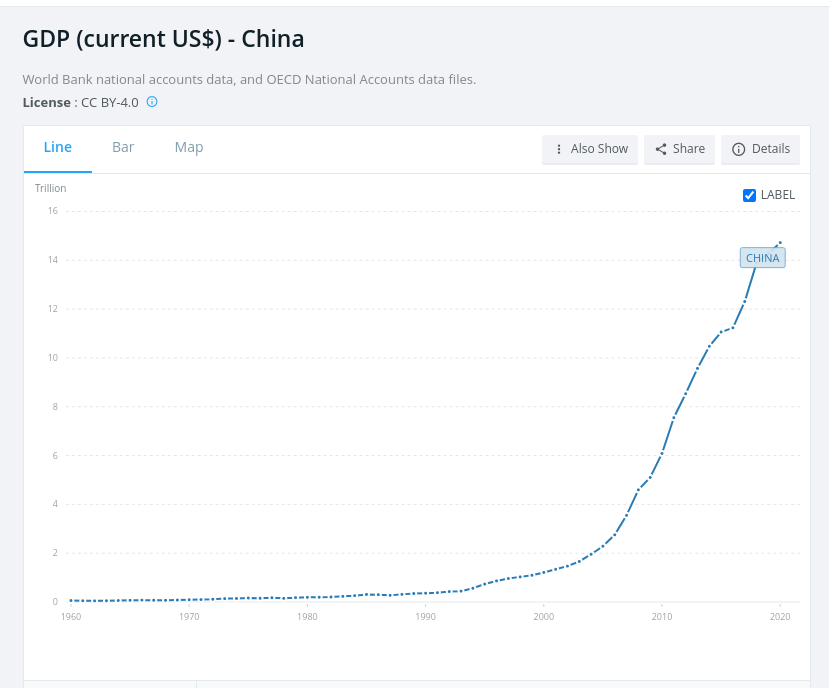

```r
gap_wide %>%
  filter(country == "China")
```

| continent | country | gdpPercap_1952 | gdpPercap_1957 | gdpPercap_1962 | gdpPercap_1967 | gdpPercap_1972 | gdpPercap_1977 | gdpPercap_1982 | gdpPercap_1987 | gdpPercap_1992 | gdpPercap_1997 | gdpPercap_2002 | gdpPercap_2007 | lifeExp_1952 | lifeExp_1957 | lifeExp_1962 | lifeExp_1967 | lifeExp_1972 | lifeExp_1977 | lifeExp_1982 | lifeExp_1987 | lifeExp_1992 | lifeExp_1997 | lifeExp_2002 | lifeExp_2007 | pop_1952 | pop_1957 | pop_1962 | pop_1967 | … |
| --- | --- | --- | --- | --- | --- | --- | --- | --- | --- | --- | --- | --- | --- | --- | --- | --- | --- | --- | --- | --- | --- | --- | --- | --- | --- | --- | --- | --- | --- | --- |
| Asia | China | 400.4486 | 575.987 | 487.674 | 612.7057 | 676.9001 | 741.2375 | 962.4214 | 1378.904 | 1655.784 | 2289.234 | 3119.281 | 4959.115 | 44 | 50.54896 | 44.50136 | 58.38112 | 63.11888 | 63.96736 | 65.525 | 67.274 | 68.69 | 70.426 | 72.028 | 72.961 | 556263528 | 637408000 | 665770000 | 754550000 | … |

How to plot ?

### Wide vs long

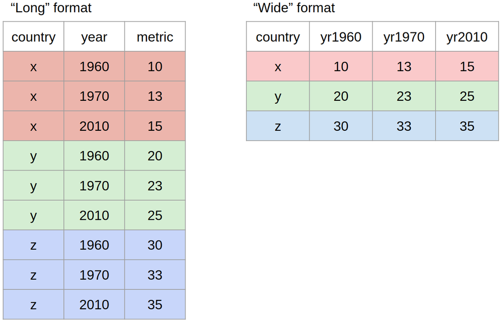

- Wide data is for humans
- Long data is for computers

#### Wide to long

```r
gap_wide %>%
  pivot_longer(gdpPercap_1952:gdpPercap_2007,
               names_to = )
```

| continent | country | lifeExp_1952 | lifeExp_1957 | lifeExp_1962 | lifeExp_1967 | lifeExp_1972 | lifeExp_1977 | lifeExp_1982 | lifeExp_1987 | lifeExp_1992 | lifeExp_1997 | lifeExp_2002 | lifeExp_2007 | pop_1952 | pop_1957 | pop_1962 | pop_1967 | pop_1972 | pop_1977 | pop_1982 | pop_1987 | pop_1992 | pop_1997 | pop_2002 | pop_2007 | name | value |
| --- | --- | --- | --- | --- | --- | --- | --- | --- | --- | --- | --- | --- | --- | --- | --- | --- | --- | --- | --- | --- | --- | --- | --- | --- | --- | --- | --- |
| Africa | Algeria | 43.077 | 45.68500 | 48.30300 | 51.40700 | 54.51800 | 58.01400 | 61.368 | 65.799 | 67.744 | 69.152 | 70.994 | 72.301 | 9279525 | 10270856 | 11000948 | 12760499 | 14760787 | 17152804 | 20033753 | 23254956 | 26298373 | 29072015 | 31287142 | 33333216 | gdpPercap_1952 | 2449.0082 |
| Africa | Algeria | 43.077 | 45.68500 | 48.30300 | 51.40700 | 54.51800 | 58.01400 | 61.368 | 65.799 | 67.744 | 69.152 | 70.994 | 72.301 | 9279525 | 10270856 | 11000948 | 12760499 | 14760787 | 17152804 | 20033753 | 23254956 | 26298373 | 29072015 | 31287142 | 33333216 | gdpPercap_1957 | 3013.9760 |
| Africa | Algeria | 43.077 | 45.68500 | 48.30300 | 51.40700 | 54.51800 | 58.01400 | 61.368 | 65.799 | 67.744 | 69.152 | 70.994 | 72.301 | 9279525 | 10270856 | 11000948 | 12760499 | 14760787 | 17152804 | 20033753 | 23254956 | 26298373 | 29072015 | 31287142 | 33333216 | gdpPercap_1962 | 2550.8169 |
| Africa | Algeria | 43.077 | 45.68500 | 48.30300 | 51.40700 | 54.51800 | 58.01400 | 61.368 | 65.799 | 67.744 | 69.152 | 70.994 | 72.301 | 9279525 | 10270856 | 11000948 | 12760499 | 14760787 | 17152804 | 20033753 | 23254956 | 26298373 | 29072015 | 31287142 | 33333216 | gdpPercap_1967 | 3246.9918 |
| Africa | Algeria | 43.077 | 45.68500 | 48.30300 | 51.40700 | 54.51800 | 58.01400 | 61.368 | 65.799 | 67.744 | 69.152 | 70.994 | 72.301 | 9279525 | 10270856 | 11000948 | 12760499 | 14760787 | 17152804 | 20033753 | 23254956 | 26298373 | 29072015 | 31287142 | 33333216 | gdpPercap_1972 | 4182.6638 |
| Africa | Algeria | 43.077 | 45.68500 | 48.30300 | 51.40700 | 54.51800 | 58.01400 | 61.368 | 65.799 | 67.744 | 69.152 | 70.994 | 72.301 | 9279525 | 10270856 | 11000948 | 12760499 | 14760787 | 17152804 | 20033753 | 23254956 | 26298373 | 29072015 | 31287142 | 33333216 | gdpPercap_1977 | 4910.4168 |
| Africa | Algeria | 43.077 | 45.68500 | 48.30300 | 51.40700 | 54.51800 | 58.01400 | 61.368 | 65.799 | 67.744 | 69.152 | 70.994 | 72.301 | 9279525 | 10270856 | 11000948 | 12760499 | 14760787 | 17152804 | 20033753 | 23254956 | 26298373 | 29072015 | 31287142 | 33333216 | gdpPercap_1982 | 5745.1602 |
| Africa | Algeria | 43.077 | 45.68500 | 48.30300 | 51.40700 | 54.51800 | 58.01400 | 61.368 | 65.799 | 67.744 | 69.152 | 70.994 | 72.301 | 9279525 | 10270856 | 11000948 | 12760499 | 14760787 | 17152804 | 20033753 | 23254956 | 26298373 | 29072015 | 31287142 | 33333216 | gdpPercap_1987 | 5681.3585 |
| Africa | Algeria | 43.077 | 45.68500 | 48.30300 | 51.40700 | 54.51800 | 58.01400 | 61.368 | 65.799 | 67.744 | 69.152 | 70.994 | 72.301 | 9279525 | 10270856 | 11000948 | 12760499 | 14760787 | 17152804 | 20033753 | 23254956 | 26298373 | 29072015 | 31287142 | 33333216 | gdpPercap_1992 | 5023.2166 |
| Africa | Algeria | 43.077 | 45.68500 | 48.30300 | 51.40700 | 54.51800 | 58.01400 | 61.368 | 65.799 | 67.744 | 69.152 | 70.994 | 72.301 | 9279525 | 10270856 | 11000948 | 12760499 | 14760787 | 17152804 | 20033753 | 23254956 | 26298373 | 29072015 | 31287142 | 33333216 | gdpPercap_1997 | 4797.2951 |

[output cut: 1694 more lines]